# Image Analysis in Python: Filtering

⇦ Back

This tutorial will look at how to apply median and smoothing filters to images.

# 1 Python Packages

The code on this page uses the NumPy and Matplotlib packages which can be installed from the terminal via the following:

```bash
# "python3.12" should correspond to the version of Python you are using
python3.12 -m pip install numpy
python3.12 -m pip install matplotlib
```

Once finished, import these packages into your Python script as follows:

```python
# NumPy is the fundamental package for scientific computing with Python
import numpy as np
# Matplotlib is for creating static, animated and interactive visualizations
from matplotlib import pyplot as plt
```

If you’re on an Ubuntu machine or similar it’s possible that you will need to change some environment variables to be compatible with the Wayland system:

```python
# os provides a portable way of using operating system dependent functionality
import os

# Set the QT_QPA_PLATFORM environment variable to wayland
os.environ['QT_QPA_PLATFORM'] = 'wayland'
# Set the Matplotlib backend to one that is compatible with Wayland
plt.switch_backend('Agg')
```

# 2 Import an Image

Assuming that there is an image file called `malaria.jpg` in the same folder as your script, import it via the following:

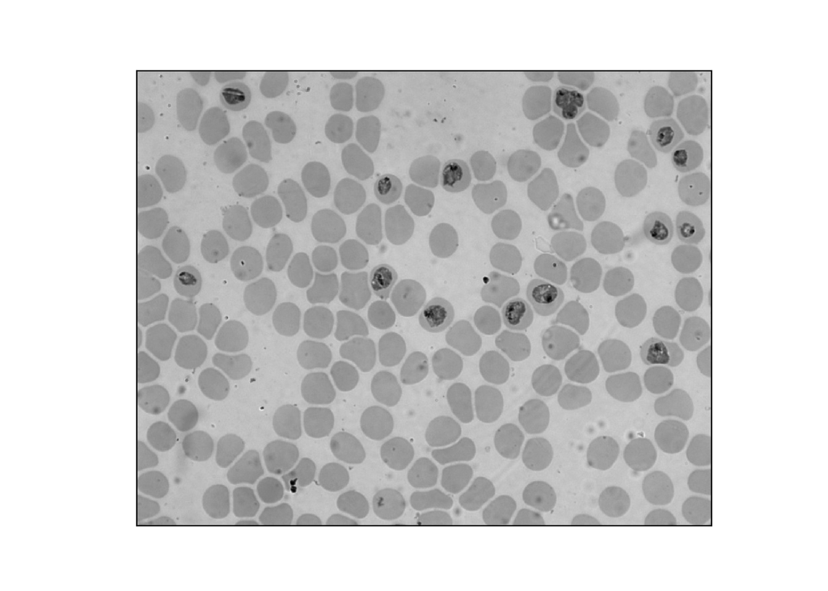

```python
filename = 'malaria.jpg'
img = plt.imread(filename)
plt.xticks([])
plt.yticks([])
plt.imshow(img)
```

Images will usually be imported as three-dimensional arrays of numbers: a 2D image with a third dimension containing the red, green and blue (RGB) colour values for each pixel:

```python
print(np.shape(img))
```

```
## (683, 862, 3)
```

In this example the image is 683 pixels in height, 862 in width and has three colour values (red, green and blue) for each pixel. But, because it is a greyscale image, the three colour values are actually the same for each pixel. This means that we can simplify our image by flattening it into a 2D array:

```python
# Select the image's x-axis, y-axis and one layer of its z-axis
# (this works because it's a greyscale image)
img = img[:, :, 0]
print(np.shape(img))
```

```
## (683, 862)
```

Now we just have a 683x862 array of numbers.

# 3 Median Filter

A median filter looks at a ‘window’ (a subset) within the image, calculates the median value of the pixels in that window and replaces the colour value of the pixel in the centre of the window with this median value. In practice, the pixel is not replaced but a new image is created.

```python
def median_filter(img, window_size):
    """
    Apply a median filter to an image represented as an array of numbers.

    Parameters
    ----------
    img : numpy.ndarray
        2D array of values representing (greyscale) pixel colour values.
    window_size : int
        The size of the window of which the median will be calculate.

    Returns
    -------
    filtered : numpy.ndarray
        The filtered image.
    """
    # Add a border around the original image
    height, width = np.shape(img)
    size = [height + window_size - 1, width + window_size - 1]
    # Initialise a matrix of zeroes (a black image) large enough to contain the
    # original image plus a border
    img_w_border = np.zeros(size)
    # Add the original image into the middle of the initialised black image,
    # leaving a border around it
    x0 = int((window_size - 1) / 2)
    x1 = int(size[0] - (window_size - 1) / 2)
    # For each row in the middle of the initialised matrix
    for row in range(x0, x1):
        y0 = int((window_size - 1) / 2)
        y1 = int(size[1] - (window_size - 1) / 2)
        # For each column in the middle of the initialised matrix
        for column in range(y0, y1):
            # Place the corresponding pixel from the image there
            offset = int((window_size - 1) / 2)
            img_w_border[row][column] = img[row - offset][column - offset]

    # Filter the image with the border
    filtered = np.zeros(np.shape(img))
    # For each row in the initialised matrix
    for row in range(height):
        # For each column in the initialised matrix
        for col in range(width):
            # Look at a window of the image with a border
            window = img_w_border[row:row + window_size, col:col + window_size]
            # Sort the window (axis=None means the array is flattened before
            # sorting)
            window = np.sort(window, axis=None)
            # Add the median of that to the correct pixel in the filtered image
            middle_index = int(window_size * window_size / 2 + 1)
            filtered[row][col] = window[middle_index]

    return filtered
```

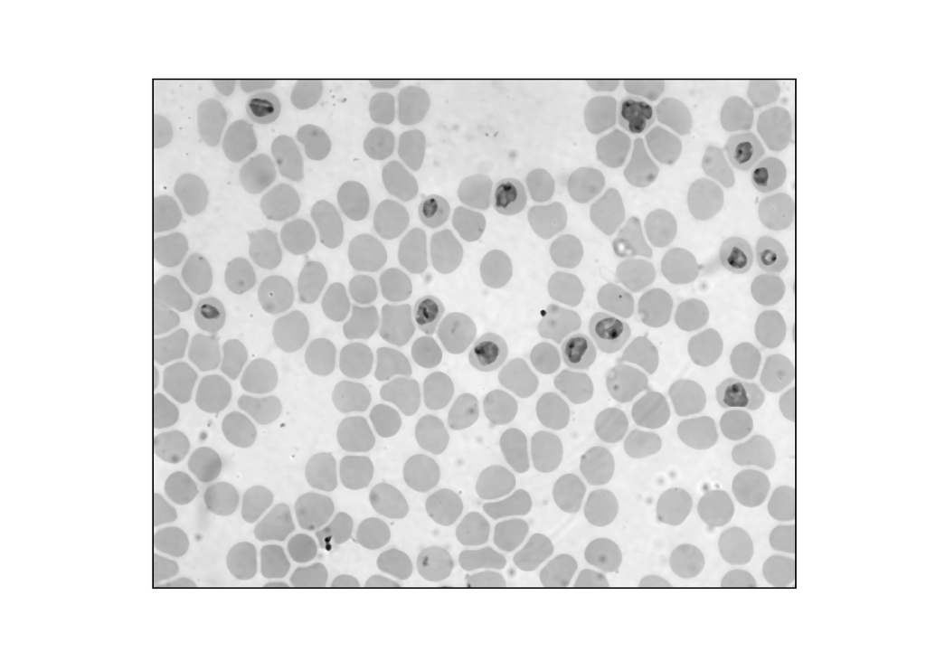

```python
filtered = median_filter(img, 5)

plt.xticks([])
plt.yticks([])
plt.imshow(filtered, cmap='gray')
```

# 4 Smooth Filter

A smooth filter is similar to a median filter except the pixels are replaced by the *mean* value of the pixels in their window:

```python
def smooth_filter(img, window_size):
    """
    Apply a smoothing filter to an image represented as an array of numbers.

    Parameters
    ----------
    img : numpy.ndarray
        2D array of values representing the (greyscale) pixels' colour values.
    window_size : int
        The size of the window of which the median will be calculate.

    Returns
    -------
    filtered : numpy.ndarray
        The filtered image.
    """
    # Add a border around the original image
    height, width = np.shape(img)
    size = [height + window_size - 1, width + window_size - 1]
    # Initialise a matrix of zeroes (a black image) large enough to contain the
    # original image plus a border
    img_w_border = np.zeros(size)
    # Add the original image into the middle of the initialised black image,
    # leaving a border around it
    x0 = int((window_size - 1) / 2)
    x1 = int(size[0] - (window_size - 1) / 2)
    # For each row in the middle of the initialised matrix
    for row in range(x0, x1):
        y0 = int((window_size - 1) / 2)
        y1 = int(size[1] - (window_size - 1) / 2)
        # For each column in the middle of the initialised matrix
        for column in range(y0, y1):
            # Place the corresponding pixel from the image there
            offset = int((window_size - 1) / 2)
            img_w_border[row][column] = img[row - offset][column - offset]

    # Filter the image with the border
    filtered = np.zeros(np.shape(img))
    # For each row in the initialised matrix
    for row in range(height):
        # For each column in the initialised matrix
        for col in range(width):
            # Look at a window of the image with a border
            window = img_w_border[row:row + window_size, col:col + window_size]
            # Take the mean value of the window (axis=None means the array is
            # flattened before sorting)
            mean = np.mean(window, axis=None)
            # Add the mean to the correct pixel in the filtered image
            filtered[row, col] = mean

    return filtered
```

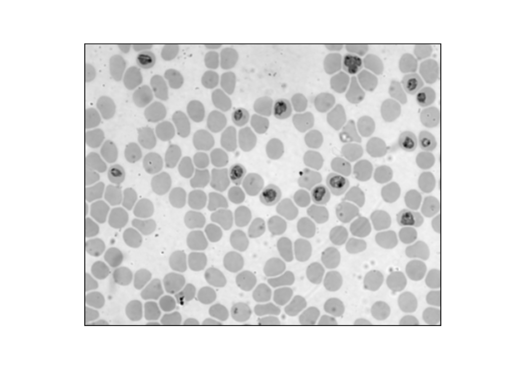

```python
filtered = smooth_filter(img, 5)

plt.xticks([])
plt.yticks([])
plt.imshow(filtered, cmap='gray')
```

# 5 Effect of Window Size

A larger window essentially means more filtering. The image loses detail as the pixels become more ‘average’ (more similar to each other):

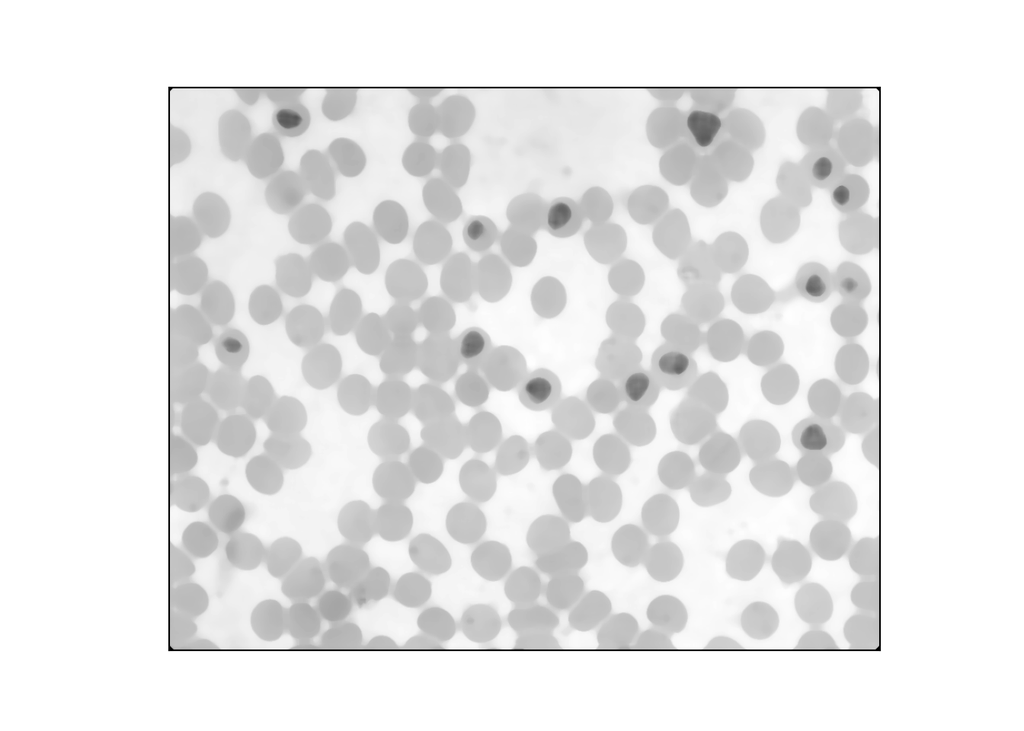

```python
filtered = median_filter(img, 15)
plt.xticks([])
plt.yticks([])
plt.imshow(filtered, cmap='gray')
```

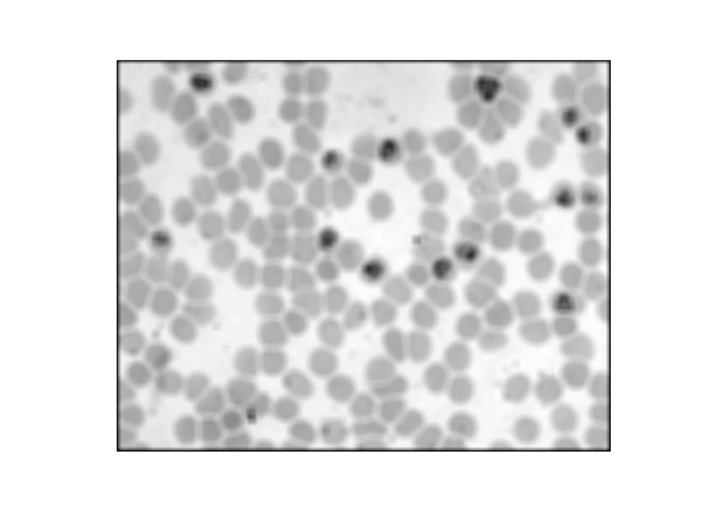

```python
filtered = smooth_filter(img, 15)
plt.xticks([])
plt.yticks([])
plt.imshow(filtered, cmap='gray')
```

# 6 Effect of Filter Type

Smooth/average/mean filters result in images that are more blurred than median filters. Think of how smooth filters work: they cause pixels to change colour so as to be more similar to the typical (average) pixel that surrounds it. Thus, the difference between each pixel and its neighbours reduces, and so regions of pixels start to blend into each other.

Smooth filtering also results in a greater loss of contrast that median filtering. This is because the more extreme tones (the very dark and the very light pixels) become more ‘average’ in their intensity.

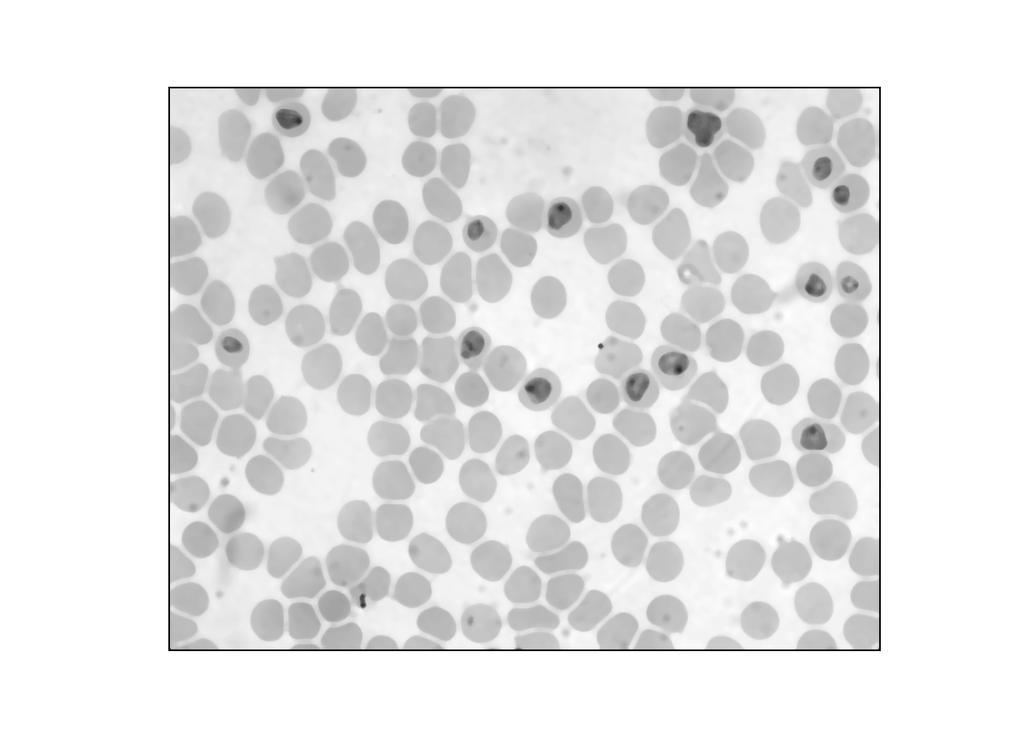

```python
filtered = median_filter(img, 9)
plt.xticks([])
plt.yticks([])
plt.imshow(filtered, cmap='gray')
```

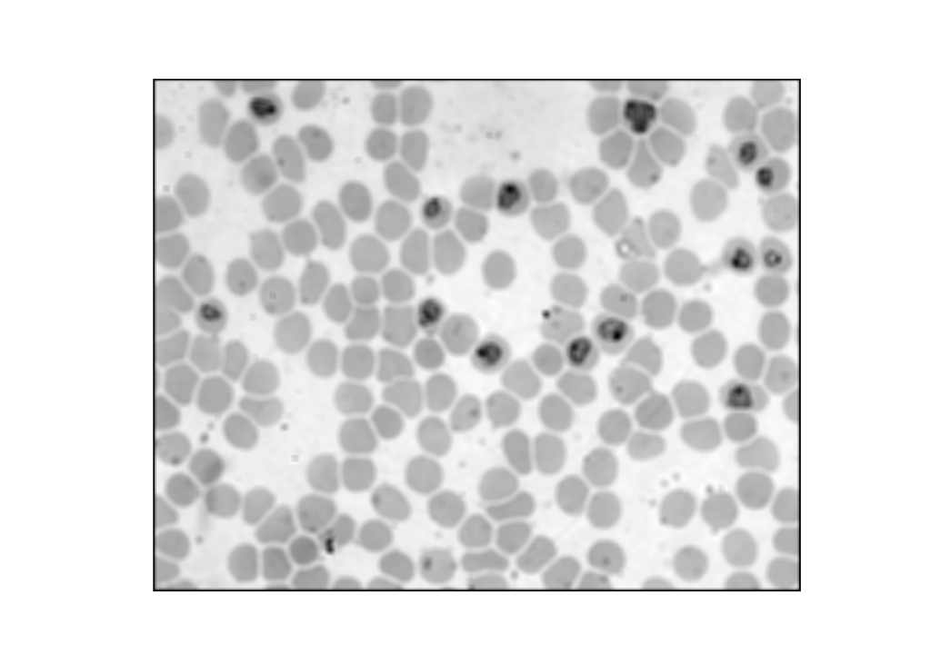

```python
filtered = smooth_filter(img, 9)
plt.xticks([])
plt.yticks([])
plt.imshow(filtered, cmap='gray')
```

⇦ Back